# Class 8

## Required files

1. muchado-edgelist.txt
2. Hacking8-Network.R

## Today’s Commands

install.packages() library() -> require can be used, not sure what the exact differences are {igraph} A library for network analysis: igraph.org subset.data.frame() graph.data.frame{igraph}

## Beginning of class

Thursday will be focused on Much ado

We talk about graphs and stuff

Can catch flavor of an author from function words - other thigns

Seven Bridges of Konigsberg - First graph theory problem

Finding Paul Revere using only metadata

Adjacency Matrix and resulting graph -Only need 1 half unless it is a directed graph

We had issues with the AV system

Discussed onion article titled: Professor having trouble with audio visual https://www.theonion.com/ask-a-college-professor-having-trouble-with-the-audiovi-1819584653

We then watch the Watch and Constable Dogberry sceen - the one with the Sexton

## Script explained

install.packages(“igraph”) only needs to be done once -Sometimes dependencies will make this more difficult

library(“igraph”) then attaches igraph to the session

we then import muchado-edgelist.txt as a dataframe dataframe allows for multiple data types. A matrix would not allow for different data types.

```r
knitr::opts_chunk$set(echo = TRUE)
```

```r
# Social Networks in Literature
# February 11, 2020

# install.packages("igraph") # Only needs to be done once.
library("igraph") # Attaches igraph to the session
#setwd("~/projects/hack/igraph")

# Reading tables ------------
# Read in information about dialogue in Much Ado...
# I've created a representation of who speaks to whom in each scene, marking exchanges only once per scene.
# That is if Beatrice and Benedick go back and forth for several lines, I record only:
# BEAT\tBEN and BEN\tBEA
# soliloquy and asides and oaths are marked with an "x"
ado.df<-read.table('muchado-edgelist.txt', header=T) # strings come in as factors, compare read.table('muchado-edgelist.txt', header=T, stringsAsFactors=F)
View(ado.df) # a data-frame (mixes data types)!
class(ado.df[,1]) == class(ado.df[,3])
```

```
## [1] FALSE
```

```r
# Subsetting (Tricks) --------
ado.df$char1 # factors (categorical variables)
```

```
##   [1] LEON  MESS  BEAT  HERO  LEON  BEAT  MESS  PEDRO LEON  BEN   LEON  PEDRO
##  [13] PEDRO BEN   BEAT  BEN   PEDRO LEON  JOHN  CLAUD BEN   CLAUD LEON  ANTON
##  [25] CONR  JOHN  JOHN  BORA  LEON  ANTON HERO  BEAT  LEON  BEAT  BEAT  ANTON
##  [37] LEON  PEDRO HERO  BALTH MARG  URSU  ANTON BEAT  BEN   JOHN  BORA  JOHN
##  [49] CLAUD BORA  CLAUD BEN   CLAUD PEDRO BEN   PEDRO BEAT  PEDRO CLAUD LEON
##  [61] BEAT  CLAUD CLAUD BEAT  PEDRO LEON  JOHN  BORA  BEN   BOY   BEN   PEDRO
##  [73] CLAUD PEDRO BALTH LEON  LEON  CLAUD PEDRO BEAT  HERO  MARG  HERO  URSU
##  [85] BEAT  PEDRO CLAUD BEN   BEN   BEN   LEON  CLAUD PEDRO BEN   PEDRO CLAUD
##  [97] LEON  BEN   LEON  PEDRO JOHN  PEDRO CLAUD JOHN  DOGB  VERG  DOGB  WATCH
## [109] DOGB  SEAC  BORA  WATCH CONR  CONR  WATCH HERO  URSU  HERO  MARG  HERO
## [121] BEAT  MARG  BEAT  LEON  DOGB  VERG  DOGB  VERG  LEON  LEON  FRIAR CLAUD
## [133] FRIAR HERO  CLAUD HERO  FRIAR CLAUD BEN   CLAUD LEON  PEDRO CLAUD LEON
## [145] PEDRO JOHN  HERO  CLAUD LEON  HERO  PEDRO JOHN  LEON  BEAT  JOHN  BEN
## [157] BEAT  FRIAR BEN   LEON  FRIAR BEN   DOGB  DOGB  SEXT  DOGB  VERG  DOGB
## [169] BORA  DOGB  CONR  WATCH SEXT  WATCH CONR  ANTON LEON  PEDRO PEDRO CLAUD
## [181] CLAUD LEON  LEON  ANTON CLAUD BEN   PEDRO BEN   DOGB  DOGB  PEDRO DOGB
## [193] PEDRO PEDRO BORA  CLAUD DOGB  VERG  LEON  BORA  LEON  DOGB  LEON  LEON
## [205] BEN   MARG  BEN   BEAT  BEN   URSU  CLAUD CLAUD PEDRO PEDRO CLAUD FRIAR
## [217] LEON  ANTON BEN   LEON  LEON  LEON  LEON  LEON  BEN   FRIAR LEON  BEN
## [229] PEDRO PEDRO PEDRO PEDRO LEON  LEON  CLAUD BEN   CLAUD CLAUD CLAUD HERO
## [241] PEDRO FRIAR FRIAR BEN   BEAT  MESS
## 21 Levels: ANTON BALTH BEAT BEN BORA BOY CLAUD CONR DOGB FRIAR HERO ... WATCH
```

```r
as.character(ado.df$char1) # as a character vector
```

```
##   [1] "LEON"  "MESS"  "BEAT"  "HERO"  "LEON"  "BEAT"  "MESS"  "PEDRO" "LEON"
##  [10] "BEN"   "LEON"  "PEDRO" "PEDRO" "BEN"   "BEAT"  "BEN"   "PEDRO" "LEON"
##  [19] "JOHN"  "CLAUD" "BEN"   "CLAUD" "LEON"  "ANTON" "CONR"  "JOHN"  "JOHN"
##  [28] "BORA"  "LEON"  "ANTON" "HERO"  "BEAT"  "LEON"  "BEAT"  "BEAT"  "ANTON"
##  [37] "LEON"  "PEDRO" "HERO"  "BALTH" "MARG"  "URSU"  "ANTON" "BEAT"  "BEN"
##  [46] "JOHN"  "BORA"  "JOHN"  "CLAUD" "BORA"  "CLAUD" "BEN"   "CLAUD" "PEDRO"
##  [55] "BEN"   "PEDRO" "BEAT"  "PEDRO" "CLAUD" "LEON"  "BEAT"  "CLAUD" "CLAUD"
##  [64] "BEAT"  "PEDRO" "LEON"  "JOHN"  "BORA"  "BEN"   "BOY"   "BEN"   "PEDRO"
##  [73] "CLAUD" "PEDRO" "BALTH" "LEON"  "LEON"  "CLAUD" "PEDRO" "BEAT"  "HERO"
##  [82] "MARG"  "HERO"  "URSU"  "BEAT"  "PEDRO" "CLAUD" "BEN"   "BEN"   "BEN"
##  [91] "LEON"  "CLAUD" "PEDRO" "BEN"   "PEDRO" "CLAUD" "LEON"  "BEN"   "LEON"
## [100] "PEDRO" "JOHN"  "PEDRO" "CLAUD" "JOHN"  "DOGB"  "VERG"  "DOGB"  "WATCH"
## [109] "DOGB"  "SEAC"  "BORA"  "WATCH" "CONR"  "CONR"  "WATCH" "HERO"  "URSU"
## [118] "HERO"  "MARG"  "HERO"  "BEAT"  "MARG"  "BEAT"  "LEON"  "DOGB"  "VERG"
## [127] "DOGB"  "VERG"  "LEON"  "LEON"  "FRIAR" "CLAUD" "FRIAR" "HERO"  "CLAUD"
## [136] "HERO"  "FRIAR" "CLAUD" "BEN"   "CLAUD" "LEON"  "PEDRO" "CLAUD" "LEON"
## [145] "PEDRO" "JOHN"  "HERO"  "CLAUD" "LEON"  "HERO"  "PEDRO" "JOHN"  "LEON"
## [154] "BEAT"  "JOHN"  "BEN"   "BEAT"  "FRIAR" "BEN"   "LEON"  "FRIAR" "BEN"
## [163] "DOGB"  "DOGB"  "SEXT"  "DOGB"  "VERG"  "DOGB"  "BORA"  "DOGB"  "CONR"
## [172] "WATCH" "SEXT"  "WATCH" "CONR"  "ANTON" "LEON"  "PEDRO" "PEDRO" "CLAUD"
## [181] "CLAUD" "LEON"  "LEON"  "ANTON" "CLAUD" "BEN"   "PEDRO" "BEN"   "DOGB"
## [190] "DOGB"  "PEDRO" "DOGB"  "PEDRO" "PEDRO" "BORA"  "CLAUD" "DOGB"  "VERG"
## [199] "LEON"  "BORA"  "LEON"  "DOGB"  "LEON"  "LEON"  "BEN"   "MARG"  "BEN"
## [208] "BEAT"  "BEN"   "URSU"  "CLAUD" "CLAUD" "PEDRO" "PEDRO" "CLAUD" "FRIAR"
## [217] "LEON"  "ANTON" "BEN"   "LEON"  "LEON"  "LEON"  "LEON"  "LEON"  "BEN"
## [226] "FRIAR" "LEON"  "BEN"   "PEDRO" "PEDRO" "PEDRO" "PEDRO" "LEON"  "LEON"
## [235] "CLAUD" "BEN"   "CLAUD" "CLAUD" "CLAUD" "HERO"  "PEDRO" "FRIAR" "FRIAR"
## [244] "BEN"   "BEAT"  "MESS"
```

```r
class(ado.df$act.sc)
```

```
## [1] "numeric"
```

```r
ado.df$act.sc
```

```
##   [1] 1.1 1.1 1.1 1.1 1.1 1.1 1.1 1.1 1.1 1.1 1.1 1.1 1.1 1.1 1.1 1.1 1.1 1.1
##  [19] 1.1 1.1 1.1 1.1 1.2 1.2 1.3 1.3 1.3 1.3 2.1 2.1 2.1 2.1 2.1 2.1 2.1 2.1
##  [37] 2.1 2.1 2.1 2.1 2.1 2.1 2.1 2.1 2.1 2.1 2.1 2.1 2.1 2.1 2.1 2.1 2.1 2.1
##  [55] 2.1 2.1 2.1 2.1 2.1 2.1 2.1 2.1 2.1 2.1 2.1 2.1 2.2 2.2 2.3 2.3 2.3 2.3
##  [73] 2.3 2.3 2.3 2.3 2.3 2.3 2.3 2.3 3.1 3.1 3.1 3.1 3.1 3.2 3.2 3.2 3.2 3.2
##  [91] 3.2 3.2 3.2 3.2 3.2 3.2 3.2 3.2 3.2 3.2 3.2 3.2 3.2 3.2 3.3 3.3 3.3 3.3
## [109] 3.3 3.3 3.3 3.3 3.3 3.3 3.3 3.4 3.4 3.4 3.4 3.4 3.4 3.4 3.4 3.5 3.5 3.5
## [127] 3.5 3.5 3.5 4.1 4.1 4.1 4.1 4.1 4.1 4.1 4.1 4.1 4.1 4.1 4.1 4.1 4.1 4.1
## [145] 4.1 4.1 4.1 4.1 4.1 4.1 4.1 4.1 4.1 4.1 4.1 4.1 4.1 4.1 4.1 4.1 4.1 4.1
## [163] 4.2 4.2 4.2 4.2 4.2 4.2 4.2 4.2 4.2 4.2 4.2 4.2 4.2 5.1 5.1 5.1 5.1 5.1
## [181] 5.1 5.1 5.1 5.1 5.1 5.1 5.1 5.1 5.1 5.1 5.1 5.1 5.1 5.1 5.1 5.1 5.1 5.1
## [199] 5.1 5.1 5.1 5.1 5.1 5.1 5.2 5.2 5.2 5.2 5.2 5.2 5.3 5.3 5.3 5.3 5.3 5.4
## [217] 5.4 5.4 5.4 5.4 5.4 5.4 5.4 5.4 5.4 5.4 5.4 5.4 5.4 5.4 5.4 5.4 5.4 5.4
## [235] 5.4 5.4 5.4 5.4 5.4 5.4 5.4 5.4 5.4 5.4 5.4 5.4
```

```r
which(ado.df$act.sc==4.2) # Dogberry and "malefactors" before the Sexton
```

```
##  [1] 163 164 165 166 167 168 169 170 171 172 173 174 175
```

```r
ado.df[which(ado.df$act.sc==4.2),] # same subsetting, more verbose
```

```
##     char1 char2 act.sc
## 163  DOGB  VERG    4.2
## 164  DOGB  SEXT    4.2
## 165  SEXT  DOGB    4.2
## 166  DOGB  SEXT    4.2
## 167  VERG  SEXT    4.2
## 168  DOGB  BORA    4.2
## 169  BORA  DOGB    4.2
## 170  DOGB  CONR    4.2
## 171  CONR  DOGB    4.2
## 172 WATCH  DOGB    4.2
## 173  SEXT WATCH    4.2
## 174 WATCH  SEXT    4.2
## 175  CONR  VERG    4.2
```

```r
grep("1.",ado.df$act.sc)
```

```
##  [1]  1  2  3  4  5  6  7  8  9 10 11 12 13 14 15 16 17 18 19 20 21 22 23 24 25
## [26] 26 27 28
```

```r
ado.df[grep("1.",ado.df$act.sc),]
```

```
##    char1 char2 act.sc
## 1   LEON  MESS    1.1
## 2   MESS  LEON    1.1
## 3   BEAT  MESS    1.1
## 4   HERO  LEON    1.1
## 5   LEON  BEAT    1.1
## 6   BEAT  LEON    1.1
## 7   MESS  BEAT    1.1
## 8  PEDRO  LEON    1.1
## 9   LEON PEDRO    1.1
## 10   BEN  LEON    1.1
## 11  LEON   BEN    1.1
## 12 PEDRO   BEN    1.1
## 13 PEDRO  HERO    1.1
## 14   BEN     x    1.1
## 15  BEAT   BEN    1.1
## 16   BEN  BEAT    1.1
## 17 PEDRO CLAUD    1.1
## 18  LEON  JOHN    1.1
## 19  JOHN  LEON    1.1
## 20 CLAUD   BEN    1.1
## 21   BEN CLAUD    1.1
## 22 CLAUD PEDRO    1.1
## 23  LEON ANTON    1.2
## 24 ANTON  LEON    1.2
## 25  CONR  JOHN    1.3
## 26  JOHN  CONR    1.3
## 27  JOHN  BORA    1.3
## 28  BORA  JOHN    1.3
```

```r
subset.data.frame(ado.df, char1=="DOGB")
```

```
##     char1 char2 act.sc
## 105  DOGB  VERG    3.3
## 107  DOGB WATCH    3.3
## 109  DOGB  SEAC    3.3
## 125  DOGB  LEON    3.5
## 127  DOGB  VERG    3.5
## 163  DOGB  VERG    4.2
## 164  DOGB  SEXT    4.2
## 166  DOGB  SEXT    4.2
## 168  DOGB  BORA    4.2
## 170  DOGB  CONR    4.2
## 189  DOGB  BORA    5.1
## 190  DOGB  CONR    5.1
## 192  DOGB PEDRO    5.1
## 197  DOGB  VERG    5.1
## 202  DOGB  LEON    5.1
```

```r
1<=ado.df$act.sc & ado.df$act.sc<2
```

```
##   [1]  TRUE  TRUE  TRUE  TRUE  TRUE  TRUE  TRUE  TRUE  TRUE  TRUE  TRUE  TRUE
##  [13]  TRUE  TRUE  TRUE  TRUE  TRUE  TRUE  TRUE  TRUE  TRUE  TRUE  TRUE  TRUE
##  [25]  TRUE  TRUE  TRUE  TRUE FALSE FALSE FALSE FALSE FALSE FALSE FALSE FALSE
##  [37] FALSE FALSE FALSE FALSE FALSE FALSE FALSE FALSE FALSE FALSE FALSE FALSE
##  [49] FALSE FALSE FALSE FALSE FALSE FALSE FALSE FALSE FALSE FALSE FALSE FALSE
##  [61] FALSE FALSE FALSE FALSE FALSE FALSE FALSE FALSE FALSE FALSE FALSE FALSE
##  [73] FALSE FALSE FALSE FALSE FALSE FALSE FALSE FALSE FALSE FALSE FALSE FALSE
##  [85] FALSE FALSE FALSE FALSE FALSE FALSE FALSE FALSE FALSE FALSE FALSE FALSE
##  [97] FALSE FALSE FALSE FALSE FALSE FALSE FALSE FALSE FALSE FALSE FALSE FALSE
## [109] FALSE FALSE FALSE FALSE FALSE FALSE FALSE FALSE FALSE FALSE FALSE FALSE
## [121] FALSE FALSE FALSE FALSE FALSE FALSE FALSE FALSE FALSE FALSE FALSE FALSE
## [133] FALSE FALSE FALSE FALSE FALSE FALSE FALSE FALSE FALSE FALSE FALSE FALSE
## [145] FALSE FALSE FALSE FALSE FALSE FALSE FALSE FALSE FALSE FALSE FALSE FALSE
## [157] FALSE FALSE FALSE FALSE FALSE FALSE FALSE FALSE FALSE FALSE FALSE FALSE
## [169] FALSE FALSE FALSE FALSE FALSE FALSE FALSE FALSE FALSE FALSE FALSE FALSE
## [181] FALSE FALSE FALSE FALSE FALSE FALSE FALSE FALSE FALSE FALSE FALSE FALSE
## [193] FALSE FALSE FALSE FALSE FALSE FALSE FALSE FALSE FALSE FALSE FALSE FALSE
## [205] FALSE FALSE FALSE FALSE FALSE FALSE FALSE FALSE FALSE FALSE FALSE FALSE
## [217] FALSE FALSE FALSE FALSE FALSE FALSE FALSE FALSE FALSE FALSE FALSE FALSE
## [229] FALSE FALSE FALSE FALSE FALSE FALSE FALSE FALSE FALSE FALSE FALSE FALSE
## [241] FALSE FALSE FALSE FALSE FALSE FALSE
```

```r
ado.df[1<=ado.df$act.sc & ado.df$act.sc<2,]
```

```
##    char1 char2 act.sc
## 1   LEON  MESS    1.1
## 2   MESS  LEON    1.1
## 3   BEAT  MESS    1.1
## 4   HERO  LEON    1.1
## 5   LEON  BEAT    1.1
## 6   BEAT  LEON    1.1
## 7   MESS  BEAT    1.1
## 8  PEDRO  LEON    1.1
## 9   LEON PEDRO    1.1
## 10   BEN  LEON    1.1
## 11  LEON   BEN    1.1
## 12 PEDRO   BEN    1.1
## 13 PEDRO  HERO    1.1
## 14   BEN     x    1.1
## 15  BEAT   BEN    1.1
## 16   BEN  BEAT    1.1
## 17 PEDRO CLAUD    1.1
## 18  LEON  JOHN    1.1
## 19  JOHN  LEON    1.1
## 20 CLAUD   BEN    1.1
## 21   BEN CLAUD    1.1
## 22 CLAUD PEDRO    1.1
## 23  LEON ANTON    1.2
## 24 ANTON  LEON    1.2
## 25  CONR  JOHN    1.3
## 26  JOHN  CONR    1.3
## 27  JOHN  BORA    1.3
## 28  BORA  JOHN    1.3
```

```r
act1sc3<-ado.df[which(ado.df$act.sc==1.3),]

# Try out the igraph library -----------
g <- graph.data.frame(ado.df)

str(g)
```

```
## List of 10
##  $ :List of 1
##   ..$ LEON: 'igraph.vs' Named int [1:40] 2 3 3 3 3 4 4 4 5 5 ...
##   .. ..- attr(*, "names")= chr [1:40] "MESS" "BEAT" "BEAT" "BEAT" ...
##   .. ..- attr(*, "env")=<weakref>
##   .. ..- attr(*, "graph")= chr "f620db38-4db4-11ea-8000-010000000000"
##  $ :List of 1
##   ..$ MESS: 'igraph.vs' Named int [1:3] 1 3 5
##   .. ..- attr(*, "names")= chr [1:3] "LEON" "BEAT" "PEDRO"
##   .. ..- attr(*, "env")=<weakref>
##   .. ..- attr(*, "graph")= chr "f620db38-4db4-11ea-8000-010000000000"
##  $ :List of 1
##   ..$ BEAT: 'igraph.vs' Named int [1:18] 1 1 2 4 4 4 4 5 6 6 ...
##   .. ..- attr(*, "names")= chr [1:18] "LEON" "LEON" "MESS" "HERO" ...
##   .. ..- attr(*, "env")=<weakref>
##   .. ..- attr(*, "graph")= chr "f620db38-4db4-11ea-8000-010000000000"
##  $ :List of 1
##   ..$ HERO: 'igraph.vs' Named int [1:13] 1 1 3 3 5 8 8 13 13 14 ...
##   .. ..- attr(*, "names")= chr [1:13] "LEON" "LEON" "BEAT" "BEAT" ...
##   .. ..- attr(*, "env")=<weakref>
##   .. ..- attr(*, "graph")= chr "f620db38-4db4-11ea-8000-010000000000"
##  $ :List of 1
##   ..$ PEDRO: 'igraph.vs' Named int [1:33] 1 1 1 1 1 1 1 3 4 4 ...
##   .. ..- attr(*, "names")= chr [1:33] "LEON" "LEON" "LEON" "LEON" ...
##   .. ..- attr(*, "env")=<weakref>
##   .. ..- attr(*, "graph")= chr "f620db38-4db4-11ea-8000-010000000000"
##  $ :List of 1
##   ..$ BEN: 'igraph.vs' Named int [1:28] 1 1 1 1 1 3 3 3 3 3 ...
##   .. ..- attr(*, "names")= chr [1:28] "LEON" "LEON" "LEON" "LEON" ...
##   .. ..- attr(*, "env")=<weakref>
##   .. ..- attr(*, "graph")= chr "f620db38-4db4-11ea-8000-010000000000"
##  $ :List of 1
##   ..$ JOHN: 'igraph.vs' Named int [1:11] 1 1 5 5 8 8 8 10 11 11 ...
##   .. ..- attr(*, "names")= chr [1:11] "LEON" "LEON" "PEDRO" "PEDRO" ...
##   .. ..- attr(*, "env")=<weakref>
##   .. ..- attr(*, "graph")= chr "f620db38-4db4-11ea-8000-010000000000"
##  $ :List of 1
##   ..$ CLAUD: 'igraph.vs' Named int [1:31] 1 1 1 1 1 1 3 4 4 4 ...
##   .. ..- attr(*, "names")= chr [1:31] "LEON" "LEON" "LEON" "LEON" ...
##   .. ..- attr(*, "env")=<weakref>
##   .. ..- attr(*, "graph")= chr "f620db38-4db4-11ea-8000-010000000000"
##  $ :List of 1
##   ..$ ANTON: 'igraph.vs' Named int [1:7] 1 1 1 1 4 5 14
##   .. ..- attr(*, "names")= chr [1:7] "LEON" "LEON" "LEON" "LEON" ...
##   .. ..- attr(*, "env")=<weakref>
##   .. ..- attr(*, "graph")= chr "f620db38-4db4-11ea-8000-010000000000"
##  $ :List of 1
##   ..$ CONR: 'igraph.vs' Named int [1:5] 7 11 16 17 18
##   .. ..- attr(*, "names")= chr [1:5] "JOHN" "BORA" "DOGB" "VERG" ...
##   .. ..- attr(*, "env")=<weakref>
##   .. ..- attr(*, "graph")= chr "f620db38-4db4-11ea-8000-010000000000"
##  - attr(*, "class")= chr "igraph"
```

```r
V(g) # vertices, there are 23
```

```
## + 23/23 vertices, named, from f620db3:
##  [1] LEON  MESS  BEAT  HERO  PEDRO BEN   JOHN  CLAUD ANTON CONR  BORA  BALTH
## [13] MARG  URSU  BOY   DOGB  VERG  WATCH SEAC  FRIAR SEXT  x     LORD
```

```r
E(g) # edges, there are 246
```

```
## + 246/246 edges from f620db3 (vertex names):
##  [1] LEON ->MESS  MESS ->LEON  BEAT ->MESS  HERO ->LEON  LEON ->BEAT
##  [6] BEAT ->LEON  MESS ->BEAT  PEDRO->LEON  LEON ->PEDRO BEN  ->LEON
## [11] LEON ->BEN   PEDRO->BEN   PEDRO->HERO  BEN  ->x     BEAT ->BEN
## [16] BEN  ->BEAT  PEDRO->CLAUD LEON ->JOHN  JOHN ->LEON  CLAUD->BEN
## [21] BEN  ->CLAUD CLAUD->PEDRO LEON ->ANTON ANTON->LEON  CONR ->JOHN
## [26] JOHN ->CONR  JOHN ->BORA  BORA ->JOHN  LEON ->ANTON ANTON->LEON
## [31] HERO ->BEAT  BEAT ->HERO  LEON ->BEAT  BEAT ->LEON  BEAT ->ANTON
## [36] ANTON->HERO  LEON ->HERO  PEDRO->HERO  HERO ->PEDRO BALTH->MARG
## [41] MARG ->BALTH URSU ->ANTON ANTON->URSU  BEAT ->BEN   BEN  ->BEAT
## [46] JOHN ->BORA  BORA ->JOHN  JOHN ->CLAUD CLAUD->JOHN  BORA ->CLAUD
## + ... omitted several edges
```

```r
#get all the edges
get.edgelist(g)
```

```
##        [,1]    [,2]
##   [1,] "LEON"  "MESS"
##   [2,] "MESS"  "LEON"
##   [3,] "BEAT"  "MESS"
##   [4,] "HERO"  "LEON"
##   [5,] "LEON"  "BEAT"
##   [6,] "BEAT"  "LEON"
##   [7,] "MESS"  "BEAT"
##   [8,] "PEDRO" "LEON"
##   [9,] "LEON"  "PEDRO"
##  [10,] "BEN"   "LEON"
##  [11,] "LEON"  "BEN"
##  [12,] "PEDRO" "BEN"
##  [13,] "PEDRO" "HERO"
##  [14,] "BEN"   "x"
```

[output cut: 232 more lines]

```r
class(get.edgelist(g)) #it's a matrix
```

```
## [1] "matrix"
```

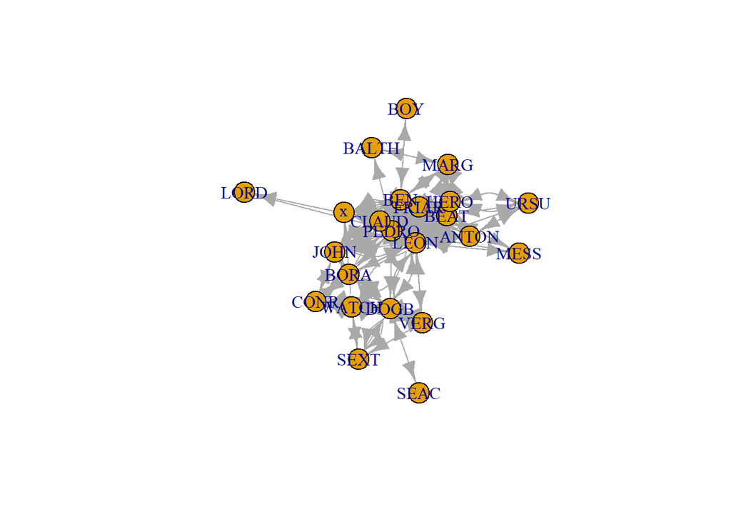

```r
# plots
plot(g) # The whole play: whoa, that's a spaghetti monster!
```

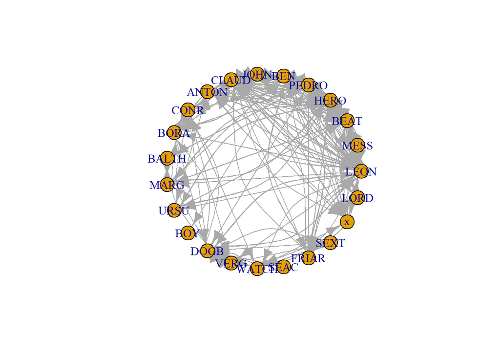

```r
plot(g, layout=layout.circle)
```

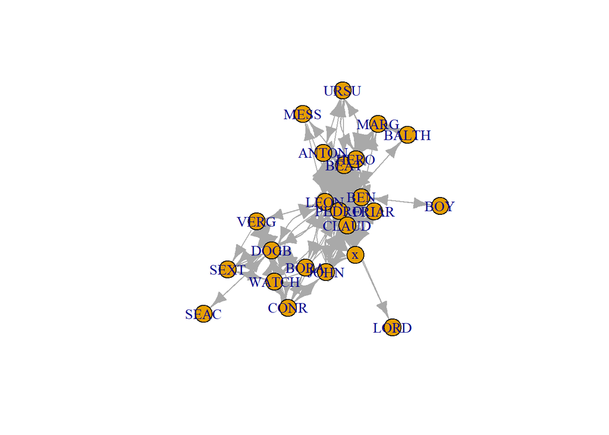

```r
plot(g, layout=layout.fruchterman.reingold)
```

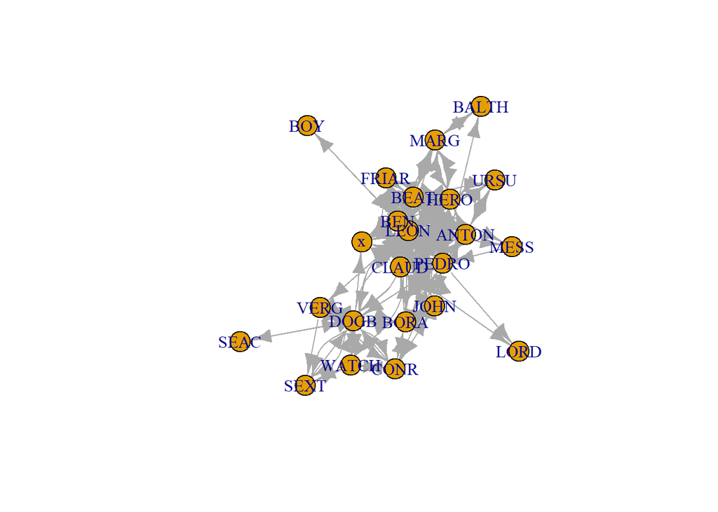

```r
plot(g, layout=layout.graphopt)
```

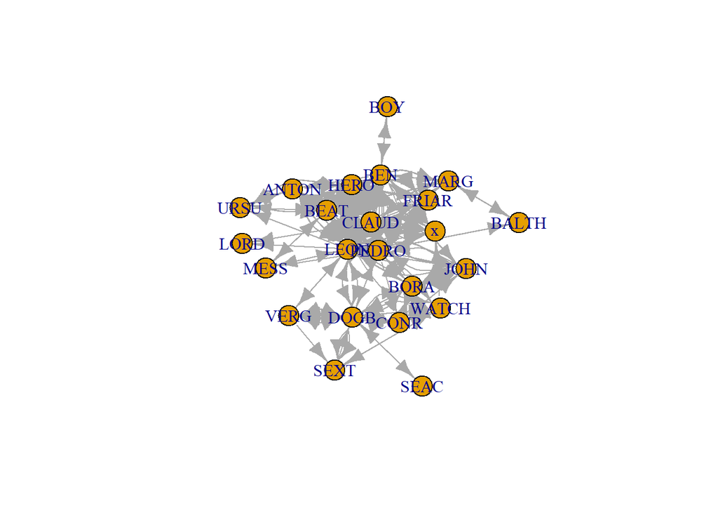

```r
plot(g, layout=layout.kamada.kawai)
```

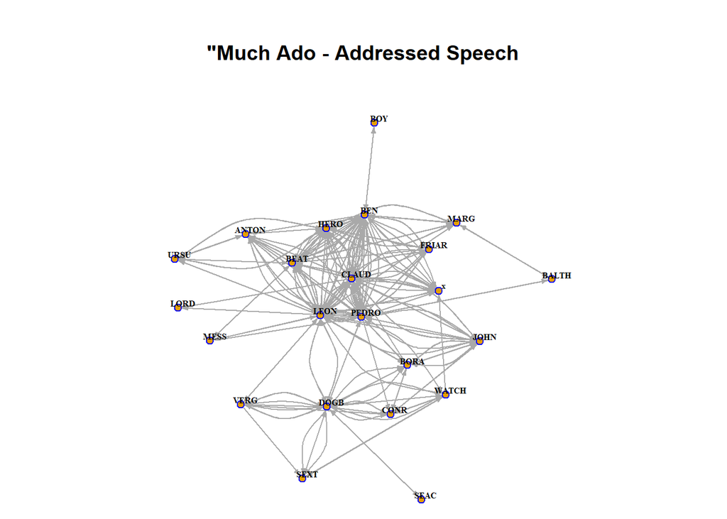

```r
# prettify that plot?
# prettier plots: http://igraph.org/r/doc/plot.common.html
par(mai=c(0,0,1,0))
plot(g,         #the graph to be plotted
     layout=layout.kamada.kawai,    # the layout method. see the igraph documentation for details
     main='"Much Ado - Addressed Speech',   #specifies the title
     vertex.size=4,
     edge.arrow.size=.3,
     vertex.label.dist=0.5,         #puts the name labels slightly off the dots
     vertex.frame.color='blue',         #the color of the border of the dots
     vertex.label.color='black',        #the color of the name labels
     vertex.label.font=2,           #the font of the name labels
     vertex.label=V(g)$name,        #specifies the labels of the vertices.
     vertex.label.cex=.5            #specifies the size of the font of the labels
)
```

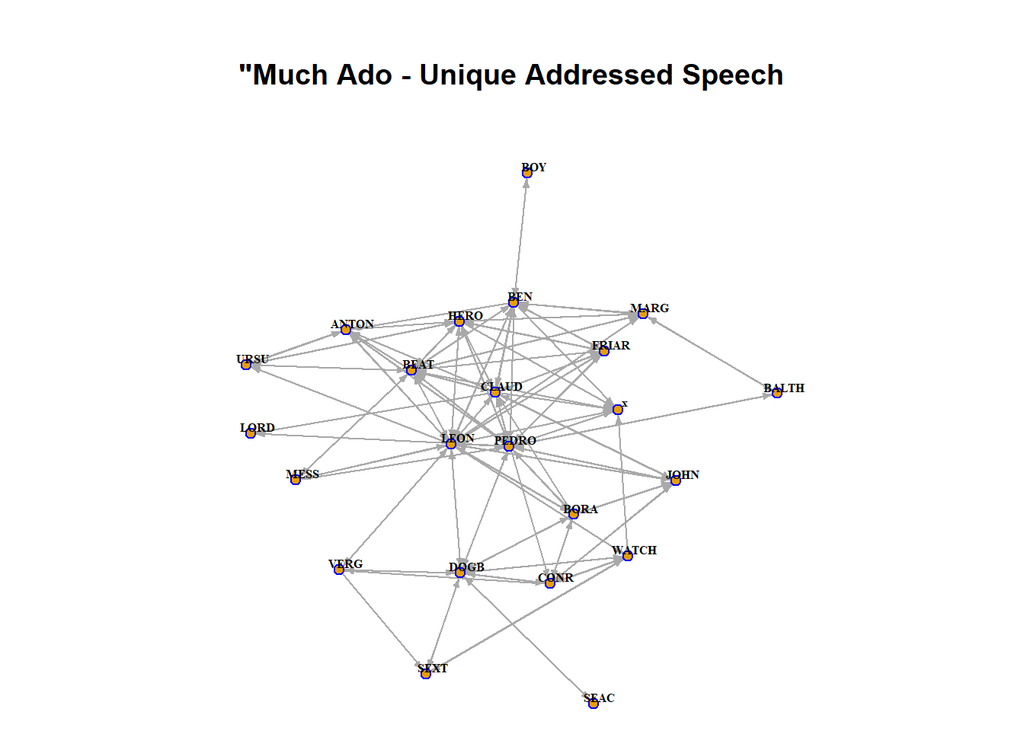

```r
# Simplify
g2<-graph.data.frame(unique(ado.df[,1:2]))
par(mai=c(0,0,1,0))
plot(g2, layout=layout.kamada.kawai, main='"Much Ado - Unique Addressed Speech',
     vertex.size=4, edge.arrow.size=.3, vertex.label.dist=0.5,
     vertex.frame.color='blue', vertex.label.color='black',
     vertex.label.font=2, vertex.label=V(g)$name,vertex.label.cex=.5
)
```

```r
# plot and save as a PDF
pdf("ado-who2whom.pdf")
plot(g2)
dev.off()
```

```r
# Simplify: Pull out a scene?
ado.df[,3] #ask for a column by number
```

```
##   [1] 1.1 1.1 1.1 1.1 1.1 1.1 1.1 1.1 1.1 1.1 1.1 1.1 1.1 1.1 1.1 1.1 1.1 1.1
##  [19] 1.1 1.1 1.1 1.1 1.2 1.2 1.3 1.3 1.3 1.3 2.1 2.1 2.1 2.1 2.1 2.1 2.1 2.1
##  [37] 2.1 2.1 2.1 2.1 2.1 2.1 2.1 2.1 2.1 2.1 2.1 2.1 2.1 2.1 2.1 2.1 2.1 2.1
##  [55] 2.1 2.1 2.1 2.1 2.1 2.1 2.1 2.1 2.1 2.1 2.1 2.1 2.2 2.2 2.3 2.3 2.3 2.3
##  [73] 2.3 2.3 2.3 2.3 2.3 2.3 2.3 2.3 3.1 3.1 3.1 3.1 3.1 3.2 3.2 3.2 3.2 3.2
##  [91] 3.2 3.2 3.2 3.2 3.2 3.2 3.2 3.2 3.2 3.2 3.2 3.2 3.2 3.2 3.3 3.3 3.3 3.3
## [109] 3.3 3.3 3.3 3.3 3.3 3.3 3.3 3.4 3.4 3.4 3.4 3.4 3.4 3.4 3.4 3.5 3.5 3.5
## [127] 3.5 3.5 3.5 4.1 4.1 4.1 4.1 4.1 4.1 4.1 4.1 4.1 4.1 4.1 4.1 4.1 4.1 4.1
## [145] 4.1 4.1 4.1 4.1 4.1 4.1 4.1 4.1 4.1 4.1 4.1 4.1 4.1 4.1 4.1 4.1 4.1 4.1
## [163] 4.2 4.2 4.2 4.2 4.2 4.2 4.2 4.2 4.2 4.2 4.2 4.2 4.2 5.1 5.1 5.1 5.1 5.1
## [181] 5.1 5.1 5.1 5.1 5.1 5.1 5.1 5.1 5.1 5.1 5.1 5.1 5.1 5.1 5.1 5.1 5.1 5.1
## [199] 5.1 5.1 5.1 5.1 5.1 5.1 5.2 5.2 5.2 5.2 5.2 5.2 5.3 5.3 5.3 5.3 5.3 5.4
## [217] 5.4 5.4 5.4 5.4 5.4 5.4 5.4 5.4 5.4 5.4 5.4 5.4 5.4 5.4 5.4 5.4 5.4 5.4
## [235] 5.4 5.4 5.4 5.4 5.4 5.4 5.4 5.4 5.4 5.4 5.4 5.4
```

```r
ado.df$act.sc #ask for a column by name
```

```
##   [1] 1.1 1.1 1.1 1.1 1.1 1.1 1.1 1.1 1.1 1.1 1.1 1.1 1.1 1.1 1.1 1.1 1.1 1.1
##  [19] 1.1 1.1 1.1 1.1 1.2 1.2 1.3 1.3 1.3 1.3 2.1 2.1 2.1 2.1 2.1 2.1 2.1 2.1
##  [37] 2.1 2.1 2.1 2.1 2.1 2.1 2.1 2.1 2.1 2.1 2.1 2.1 2.1 2.1 2.1 2.1 2.1 2.1
##  [55] 2.1 2.1 2.1 2.1 2.1 2.1 2.1 2.1 2.1 2.1 2.1 2.1 2.2 2.2 2.3 2.3 2.3 2.3
##  [73] 2.3 2.3 2.3 2.3 2.3 2.3 2.3 2.3 3.1 3.1 3.1 3.1 3.1 3.2 3.2 3.2 3.2 3.2
##  [91] 3.2 3.2 3.2 3.2 3.2 3.2 3.2 3.2 3.2 3.2 3.2 3.2 3.2 3.2 3.3 3.3 3.3 3.3
## [109] 3.3 3.3 3.3 3.3 3.3 3.3 3.3 3.4 3.4 3.4 3.4 3.4 3.4 3.4 3.4 3.5 3.5 3.5
## [127] 3.5 3.5 3.5 4.1 4.1 4.1 4.1 4.1 4.1 4.1 4.1 4.1 4.1 4.1 4.1 4.1 4.1 4.1
## [145] 4.1 4.1 4.1 4.1 4.1 4.1 4.1 4.1 4.1 4.1 4.1 4.1 4.1 4.1 4.1 4.1 4.1 4.1
## [163] 4.2 4.2 4.2 4.2 4.2 4.2 4.2 4.2 4.2 4.2 4.2 4.2 4.2 5.1 5.1 5.1 5.1 5.1
## [181] 5.1 5.1 5.1 5.1 5.1 5.1 5.1 5.1 5.1 5.1 5.1 5.1 5.1 5.1 5.1 5.1 5.1 5.1
## [199] 5.1 5.1 5.1 5.1 5.1 5.1 5.2 5.2 5.2 5.2 5.2 5.2 5.3 5.3 5.3 5.3 5.3 5.4
## [217] 5.4 5.4 5.4 5.4 5.4 5.4 5.4 5.4 5.4 5.4 5.4 5.4 5.4 5.4 5.4 5.4 5.4 5.4
## [235] 5.4 5.4 5.4 5.4 5.4 5.4 5.4 5.4 5.4 5.4 5.4 5.4
```

```r
ado.df[which(ado.df$act.sc == 4.2),] # subset rows
```

```
##     char1 char2 act.sc
## 163  DOGB  VERG    4.2
## 164  DOGB  SEXT    4.2
## 165  SEXT  DOGB    4.2
## 166  DOGB  SEXT    4.2
## 167  VERG  SEXT    4.2
## 168  DOGB  BORA    4.2
## 169  BORA  DOGB    4.2
## 170  DOGB  CONR    4.2
## 171  CONR  DOGB    4.2
## 172 WATCH  DOGB    4.2
## 173  SEXT WATCH    4.2
## 174 WATCH  SEXT    4.2
## 175  CONR  VERG    4.2
```